# STA552 Project #1

Junjie (Jason) Mei

03/19/2025

## 1 Introduction

This dataset is collected internally from a bank about the monthly loan payment amount and the current bank accounts’ balances from the bank customers with either a car loan or a personal loan. The total sample size is 1000. There are 16 variables, including 13 numerical variables and 3 categorical variable:

- Checking_amount: current Checking account’s balance
- Saving_amount: current saving account’s balance
- Amount: current loan’s monthly payment
- Term: Current loan’s payment times
- Credit_score: the customer’s credit score
- Gender: Customer’s gender (Male and Female)
- Marital_status: Customer’s marital status (Single and Married)
- Emp_status: Customer’s employed status (employed and unemployed)
- Car_loan: whether this customer has a car loan in this bank (1 and 0)
- Personal_loan: whether this customer has a personal loan in this bank (1 and 0)
- Home_loan: whether this customer has a home loan in this bank (1 and 0)
- Education_loan: whether this customer has a education loan in this bank (1 and 0)
- Age: this customer’s age
- No_of_credit_acc: how many credit card account does this customer have in this bank

In previous two assignment, we intentionally generated missing values and developed different imputation approaches to replace the missing values. In this report, we will ignore these imputation parts and go directly to linear and logistic regresstion models. Here We created one featured variables:

- TotalAmount: Numerical variable, it’s the combination of Saving_Amount and Checking-Amount.

## 2 Linear Regression

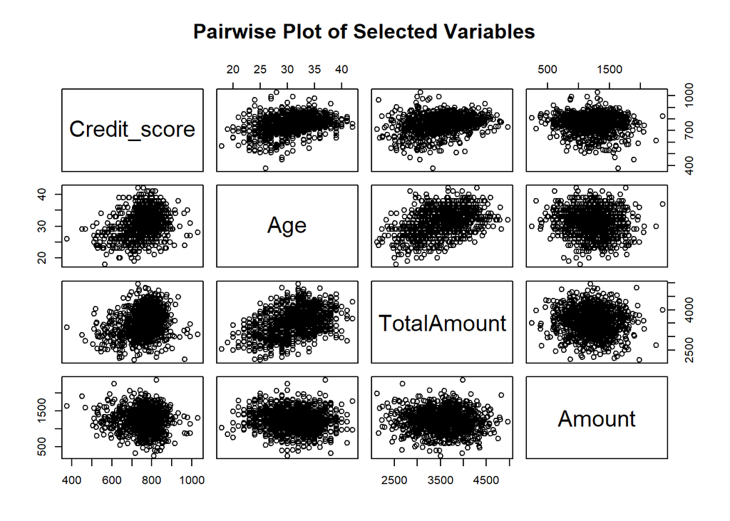

```r
# load CSV bank data
# setwd("C:/Users/Junjie Mei/Desktop/WCU/2025Spring/STA552/Week2")
mpg <- read.csv("https://jm1006958.github.io/STA552/BankLoanDefaultDataset.csv")

library(tidyverse)
#generate  feature  variables
mpg <- mutate(mpg, TotalAmount = Saving_amount + Checking_amount )

#print(mpg)
pairs(mpg[, c("Credit_score", "Age", "TotalAmount", "Amount")], main = "Pairwise Plot of Selected Variables")
```

It seems from these plots that the TotalAmount is possible to be correlated with age and credit_score. So we calculated the linear regression model to predict TotalAmount using Age + Credit_score, Age and Credit_score respectively. Based on the p-values of these three linear regression model, all of them are significantly correlated. Based on the R-squared, the combination of Age and Credit_score can explain 18.92% of the TotalAmount, and Age alone can explain 17.18% of the TotalAmount, while Credit_score alone can explain 6.797 of the TotalAmount. Here we will choose the following two linear regression models: TotalAmount = 44.7566*Age + 0.8956*Credit_score+1463.7706 and TotalAmount = 50.324*Age + 1971.114 . We use 5-fold cross-validation to select the better one from these two models without using any inferential statistics such as testing procedures or likelihood-based metrics such as AIC or SBC (BIC).

```r
#chooseCRANmirror()
#install.packages("plotly")
#library(ggplot2)
#library(plotly)
# Fit a linear regression model
model_lm <- lm(TotalAmount ~ Age + Credit_score, data = mpg)

# Summary of the model
summary(model_lm)
```

```
Call:
lm(formula = TotalAmount ~ Age + Credit_score, data = mpg)

Residuals:
     Min       1Q   Median       3Q      Max
-1266.70  -316.43    -0.36   311.00  1409.42

Coefficients:
              Estimate Std. Error t value Pr(>|t|)
(Intercept)  1463.7706   154.5487   9.471  < 2e-16 ***
Age            44.7566     3.6653  12.211  < 2e-16 ***
Credit_score    0.8956     0.1934   4.630 4.14e-06 ***
---
Signif. codes:  0 '***' 0.001 '**' 0.01 '*' 0.05 '.' 0.1 ' ' 1

Residual standard error: 447.9 on 997 degrees of freedom
Multiple R-squared:  0.1892,    Adjusted R-squared:  0.1876
F-statistic: 116.3 on 2 and 997 DF,  p-value: < 2.2e-16
```

```r
model_lm1 <- lm(TotalAmount ~ Age , data = mpg)

# Summary of the model
summary(model_lm1)
```

```
Call:
lm(formula = TotalAmount ~ Age, data = mpg)

Residuals:
     Min       1Q   Median       3Q      Max
-1258.48  -306.92     1.03   304.42  1389.49

Coefficients:
            Estimate Std. Error t value Pr(>|t|)
(Intercept) 1971.114    110.094   17.90   <2e-16 ***
Age           50.324      3.498   14.39   <2e-16 ***
---
Signif. codes:  0 '***' 0.001 '**' 0.01 '*' 0.05 '.' 0.1 ' ' 1

Residual standard error: 452.5 on 998 degrees of freedom
Multiple R-squared:  0.1718,    Adjusted R-squared:  0.171
F-statistic:   207 on 1 and 998 DF,  p-value: < 2.2e-16
```

```r
model_lm2 <- lm(TotalAmount ~ Credit_score, data = mpg)

# Summary of the model
summary(model_lm2)
```

```
Call:
lm(formula = TotalAmount ~ Credit_score, data = mpg)

Residuals:
     Min       1Q   Median       3Q      Max
-1727.68  -317.32    29.65   345.15  1466.89

Coefficients:
              Estimate Std. Error t value Pr(>|t|)
(Intercept)  2271.2487   149.6933  15.173   <2e-16 ***
Credit_score    1.6706     0.1958   8.531   <2e-16 ***
---
Signif. codes:  0 '***' 0.001 '**' 0.01 '*' 0.05 '.' 0.1 ' ' 1

Residual standard error: 480 on 998 degrees of freedom
Multiple R-squared:  0.06797,   Adjusted R-squared:  0.06703
F-statistic: 72.78 on 1 and 998 DF,  p-value: < 2.2e-16
```

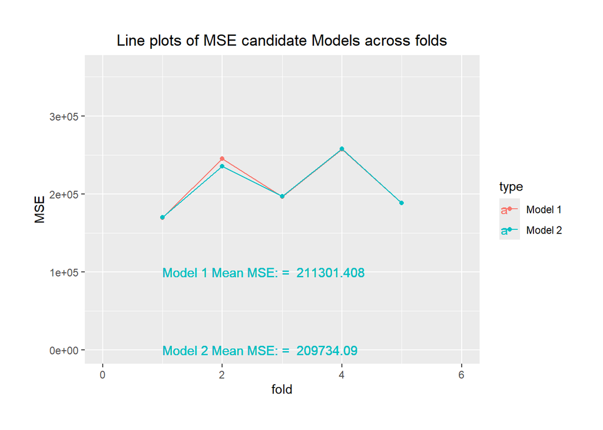

```r
# using sample() to perform random splitting
train.ID = sample(1:dim(mpg)[1], 100, replace = FALSE)  # without replacement
# training set
train = mpg[train.ID,]
test = mpg[-train.ID,]
## splitting the train set into 5 folds to train and validate the candidate models
N = dim(train)[1]   # size of training data
k = 5               # number of folds
fld.n = ceiling(N/k)
MSE.m1 = NULL       # null vector to store MSE
MSE.m2 = NULL
for (i in 1:k){
  valid.ID = ((i-1)*fld.n +1):(i*fld.n)  # observation ID for the i-th validation set
  valid.set = train[valid.ID, ]
  train.set = train[-valid.ID,]
  ## fitting two candidate models with combined 4 folds of data set
  M01 = lm(TotalAmount ~  Age + Credit_score, data = train.set)
  M02 = lm(TotalAmount ~  Age, data = train.set)
  ## Predicting InfectRsk using the two candidate models based on the validate set
  predM01 = predict(M01, newdata = valid.set)
  predM02 = predict(M02, newdata = valid.set)
  ## calculating the MSE associated with the two models
  MSE.m1[i] = mean((predM01 - valid.set$TotalAmount)^2)
  MSE.m2[i] = mean((predM02 - valid.set$TotalAmount)^2)
}
## define a data frame to store the MSE of the candidate models
##
MSE = data.frame(fold = rep(1:k,2), MSE = c(MSE.m1, MSE.m2), type=c(rep("Model 1",k), rep("Model 2", k)))
## line plots of the
cvplot = ggplot(data = MSE, aes(x=fold, y=MSE, color = type)) +
  geom_line() +
  geom_point() +
  coord_cartesian(xlim = c(0, 6),
                  ylim = c(0,360000)) +
  geom_text(mapping = aes(x=1.0, y=100000,
                          label=paste("Model 1 Mean MSE: = ", round(mean(MSE.m1),3), "")),
            hjust=0) +
  geom_text(mapping = aes(x=1.0, y=0.15,
                          label=paste("Model 2 Mean MSE: = ", round(mean(MSE.m2),3), "")),
            hjust=0) +
  ggtitle("Line plots of MSE candidate Models across folds") +
  theme(plot.title = element_text(hjust = 0.5),
        plot.margin = unit(c(1,1,1,1), "cm"))
cvplot
```

After 5-folf cross validation, these two linear regression models showed similar MSE. However, based on the larger R-squared, we will choose TotalAmount = 44.7566*Age + 0.8956*Credit_score+1463.7706 as the better model.We have measured the R-squared of this model before, then the MAE and the RMSE of this model are measured below.

```r
# fit a linear regression
ln.model <- lm(TotalAmount ~ Age + Credit_score, data = mpg)
# fitted/predicted values
fit.val <- fitted(ln.model)
# MAE
MAE = mean(abs(fit.val-mpg$TotalAmount))
MAE
```

```
[1] 361.2615
```

```r
# fit a linear regression
ln.model <- lm(TotalAmount ~ Age + Credit_score, data = mpg)
# fitted/predicted values
fit.val <- fitted(ln.model)
# MSE
RMSE = sqrt(mean((fit.val-mpg$TotalAmount)^2))
RMSE
```

```
[1] 447.2731
```

After measurement, the MAE (mean absolute error) is 361.2615, and the RMSE (Root Mean Squared Error) is 447.2731 . So here we presented TotalAmount = 44.7566*Age + 0.8956*Credit_score+1463.7706 as our linear regression model. The p-values of Age’s coefficient 44.7566, Credit_score’s coefficient 0.8956 and the intercept 1463.7706 are all below 0.001, indicating the model is very significant. Although Age and Credit_score could only explain 18.92% of TotalAmount, this is the best linear regression model we could achieve based on the limited variables of this dataset.

## 3 Logistic Regression

After trying different combination of numerical variables of TotalAmount, Age and Credit_score for the logistic regression models of Education_loan, Personal_loan, Car_loan and Home_loan, we found that the logistic model with TotalAmount and Age to predict the probability of Education_loan is statistically significant (See below).

```r
# Fit a logistic regression model
model_glm <- glm(Education_loan ~ TotalAmount + Age, family = binomial, data = mpg)

# Summary of the model
summary(model_glm)
```

```
Call:
glm(formula = Education_loan ~ TotalAmount + Age, family = binomial,
    data = mpg)

Coefficients:
              Estimate Std. Error z value Pr(>|z|)
(Intercept)  3.4467365  0.8418979   4.094 4.24e-05 ***
TotalAmount -0.0005100  0.0002297  -2.220   0.0264 *
Age         -0.1242372  0.0278550  -4.460 8.19e-06 ***
---
Signif. codes:  0 '***' 0.001 '**' 0.01 '*' 0.05 '.' 0.1 ' ' 1

(Dispersion parameter for binomial family taken to be 1)

    Null deviance: 701.35  on 999  degrees of freedom
Residual deviance: 657.42  on 997  degrees of freedom
AIC: 663.42

Number of Fisher Scoring iterations: 5
```

```r
library(caret)
# fit a logistic
model.logit <- glm(Education_loan ~ Credit_score + Age, family = binomial, data = mpg)
# predict probability of P(Y = "Yes")
probabilities <- round(as.vector(predict(model.logit, type = "response")),3)
#
thresholds <- c(0.0, 0.25, 0.5, 0.75, 1.0)

# Loop through thresholds and create confusion matrices
for (threshold in thresholds) {
  cat("\nConfusion Matrix for Threshold =", threshold, "\n")

  # Convert probabilities to predictions
  # am: 1 = manual transmission, 0 = automatic transmission
  predictions <- ifelse(probabilities > threshold, "1", "0")
  # Generate confusion matrix
  cm <- confusionMatrix(as.factor(predictions), as.factor(mpg$Education_loan), positive = "1")
  #cm$table
  print(cm$table)
}
```

```
Confusion Matrix for Threshold = 0
          Reference
Prediction   0   1
         0   0   0
         1 888 112

Confusion Matrix for Threshold = 0.25
          Reference
Prediction   0   1
         0 846  98
         1  42  14

Confusion Matrix for Threshold = 0.5
          Reference
Prediction   0   1
         0 887 112
         1   1   0

Confusion Matrix for Threshold = 0.75
          Reference
Prediction   0   1
         0 888 112
         1   0   0

Confusion Matrix for Threshold = 1
          Reference
Prediction   0   1
         0 888 112
         1   0   0
```

True Positive Rate (TPR): TP/(TP+FN) , measures the model’s ability to correctly identify positive cases.

False Positive Rate (FPR): FP/(FP+TN), measures the proportion of negative cases incorrectly classified as positive.

The ROC curve helps visualize the trade-off between sensitivity and specificity across different thresholds, providing insight into the model’s classification capability.

[figure not shown]

```r
# using the above definition of TPR and FPR
# The first number in TPR and FPR representing the top right.
# This is because both TPR and FPR are probabilities
TPR = c(1,18/(18+94), 0/(112+0), 0/(112+0), 0/(112+0), 0/(112+0))
FPR = c(1,32/(856+32), 0/(888+0), 0/(888+0), 0/(888+0), 0/(888+0))
plot(FPR, TPR, type = "b", main = "An Illustrative ROC Curve", col ="blue",
     xlab="1 - Specifity (FPR)", ylab = "Sensitivity (TPR)")
# add a off-diagonal representing random guess algorithm in binary prediction
abline(0,1, lty = 2, col = "red")
# legend
legend("bottomright", c("Logistic Model", "Random Guess"),
       col=c("blue", "red"), lty = 1:2, bty="n", cex = 0.9)
```

AUC (Area Under the Curve): The AUC quantifies the overall performance of the ROC curve into a single value, ranging from 0 to 1. There is no formula to calculate AUC unless there are specified parametric distributions of P(Y=1) and P(Y=0) respectively. The calculation is based on the approximation similar to the Riemann Sum approximation of the area under the curve in Calculus. We illustrate this using the above ROC curve.

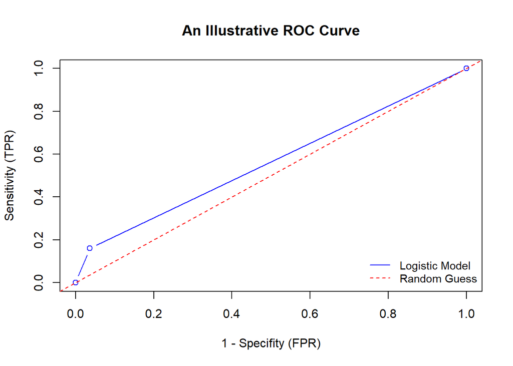

```r
# using the above definition of TPR and FPR
# The first number in TPR and FPR representing the top right.
# This is because both TPR and FPR are probabilities
TPR = c(1,18/(18+94), 0/(112+0), 0/(112+0), 0/(112+0), 0/(112+0))
FPR = c(1,32/(856+32), 0/(888+0), 0/(888+0), 0/(888+0), 0/(888+0))
plot(FPR, TPR, type = "b", main = "An Illustrative ROC Curve", col ="blue",
     xlab="1 - Specifity (FPR)", ylab = "Sensitivity (TPR)")
# add a off-diagonal representing random guess algorithm in binary prediction
abline(0,1, lty = 2, col = "red")
# legend
legend("bottomright", c("Logistic Model", "Random Guess"),
       col=c("blue", "red"), lty = 1:2, bty="n", cex = 0.9)
```

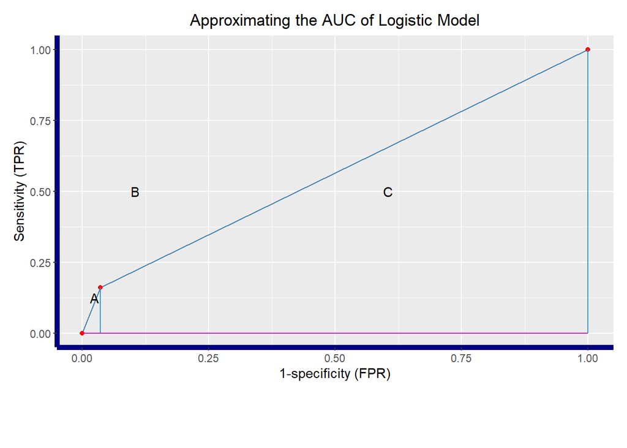

```r
# using the above definition of TPR and FPR
# The first number in TPR and FPR represents the top right.
# This is because both TPR and FPR are probabilities
TPR = round(c(1,18/(18+94), 0/(112+0), 0/(112+0), 0/(112+0), 0/(112+0)),3)
FPR = round(c(1,32/(856+32), 0/(888+0), 0/(888+0), 0/(888+0), 0/(888+0)),3)
TPR0 = TPR[7:1]
FPR0 = FPR[7:1]
#plot(FPR0, TPR0, type = "b")
datSenSpe = data.frame(TPR0, FPR0)
ggROC = ggplot(data = datSenSpe, aes(x = FPR0, y=TPR0)) +
  geom_line(col = "steelblue") +
  geom_point(col = "red") +
  geom_segment(x = FPR0, y = 0, xend = FPR0, yend = TPR0, color = 4) +
  geom_segment(x = 0, y = 0, xend = FPR0[7], yend = 0, color = 6) +
  ggtitle("Approximating the AUC of Logistic Model") +
  xlab("1-specificity (FPR)") +
  ylab("Sensitivity (TPR)") +
  annotate("text", x = 0.025, y = 0.125, label= "A") +
  annotate("text", x = 0.105, y = 0.5, label = "B") +
  annotate("text", x = 0.605, y = 0.5, label = "C") +
  theme(plot.title = element_text(hjust = 0.5),
        legend.position = c(0.8, 0.2),
        plot.margin = unit(c(0.15, 0.15, 0.75, 0.15), "inches"),
        axis.line = element_line(size = 2, colour = "navy", linetype=1))
# partition the region under the ROC into trapezoids
ggROC
```

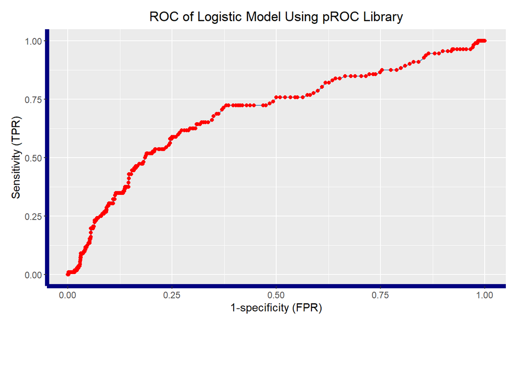

```r
library(pROC)
#fig.align='center', fig.width=5, fig.height=5,
model.logit <- glm(Education_loan ~ Credit_score + Age, family = binomial, data = mpg)
# predict probability of P(Y = "Yes")
probabilities <- round(as.vector(predict(model.logit, type = "response")),3)
##
#  category = ImputedFramingham$TenYearCHD == 1
ROCobj <- roc(mpg$Education_loan, probabilities)
Sen <- ROCobj$sensitivities
Spe <- ROCobj$specificities
pROCdata <- data.frame(TPR=Sen, FPR = (1 - Spe))
AUC <- ROCobj$auc
ggpROC = ggplot(data = pROCdata, aes(x = FPR, y=TPR)) +
  geom_line(col = "steelblue") +
  geom_point(col = "red") +
  ggtitle("ROC of Logistic Model Using pROC Library") +
  xlab("1-specificity (FPR)") +
  ylab("Sensitivity (TPR)") +
  annotate("text", x = 0.605, y = 0.5, label = as,character(AUC)) +
  theme(plot.title = element_text(hjust = 0.5),
        legend.position = c(0.8, 0.2),
        plot.margin = unit(c(0.15, 0.15, 0.75, 0.15), "inches"),
        axis.line = element_line(size = 2, colour = "navy", linetype=1))
# partition the region under the ROC into trapezoids
ggpROC
```